# 04 Biodiversity Anglerfish

Griffin Patel

April 17, 2026

# Goals

Run an analysis on the within-sample biodiversity of the samples in our project.

1. Calculate the Hill Numbers of the samples using the iNEXT package.
2. Plot and evaluate the interpolated and extrapolated rarefaction curves from iNEXT.
3. Analyze the Hill numbers as they relate to tissue type in deep-sea anglerfish.
4. Test and then answer the scientific question at hand!
1. We will need the `preprocessed_physeq` that we created in `analysis/03_PreProcessing.Rmd`, which has the chloroplasts, mitochondria, and any controls removed.

## Outputs

*This is an exciting analysis!!! We finally get to answer one of our scientific questions!*

1. Calculated biodiversity measures (Hill numbers) across every sample.
2. Figures to include in our scientific paper that visualize the data as it relates to the scientific question.
3. Statistical tests conveying the measured and quantified changes and patterns in biodiversity.

# Scientific Question

## Question & Hypotheses

How does bacterial biodiversity, measured using Hill diversity metrics (richness, Shannon diversity, and Simpson diversity), differ between luminous tissues (esca and caruncles) and non-luminous body regions (e.g., skin, gut, gills, and illicium) in deep-sea anglerfishes of the suborder Ceratioidei?

- *Null Hypothesis:* H0: Bacterial biodiversity does not statistically differ between luminous tissues and non-luminous body regions in deep-sea anglerfishes.
- *Alternative Hypothesis:* Ha: Bacterial biodiversity does statistically differ between luminous tissues and non-luminous body regions in deep-sea anglerfishes.

*Let’s get to calculating Biodiversity!*

# Set up the Environment

## Timing of this script

```r
# What time did we start running this script?
start_time <- Sys.time()
```

## Set the seed

```r
set.seed(238428)
```

## Load Packages & Colors

```r
# load packages
pacman::p_load(tidyverse, devtools, patchwork, iNEXT, phyloseq,
               ggpubr, rstatix, install = FALSE)
```

## Load in Data

```r
# Check that the expected input file exists
file.exists("data/03_PreProcessing/preprocessed_physeq.RData")
```

```
## [1] TRUE
```

```r
list.files("data/03_PreProcessing")
```

```
## [1] "preprocessed_physeq.RData"
```

```r
# Load in the preprocessed phyloseq object
load("data/03_PreProcessing/preprocessed_physeq.RData")

# take a look at it!
preprocessed_physeq
```

```
## phyloseq-class experiment-level object
## otu_table()   OTU Table:         [ 8561 taxa and 117 samples ]
## sample_data() Sample Data:       [ 117 samples by 37 sample variables ]
## tax_table()   Taxonomy Table:    [ 8561 taxa by 7 taxonomic ranks ]
```

```r
# Intuition check on seq depth
min(sample_sums(preprocessed_physeq))
```

```
## [1] 153
```

```r
# Make a metadata dataframe
metadata_df <-
  preprocessed_physeq %>%
  sample_data() %>%
  data.frame()

# add names if needed
if(!("names" %in% colnames(metadata_df))){
  metadata_df$names <- rownames(metadata_df)
}

# view of it
glimpse(metadata_df)
```

```
## Rows: 117
## Columns: 37
## $ Run                            <chr> NA, NA, NA, NA, NA, NA, NA, NA, NA, NA,…
## $ Assay.Type                     <chr> NA, NA, NA, NA, NA, NA, NA, NA, NA, NA,…
## $ AvgSpotLen                     <int> NA, NA, NA, NA, NA, NA, NA, NA, NA, NA,…
## $ Bases                          <int> NA, NA, NA, NA, NA, NA, NA, NA, NA, NA,…
## $ BioProject                     <chr> NA, NA, NA, NA, NA, NA, NA, NA, NA, NA,…
## $ BioSample                      <chr> NA, NA, NA, NA, NA, NA, NA, NA, NA, NA,…
## $ BioSampleModel                 <chr> NA, NA, NA, NA, NA, NA, NA, NA, NA, NA,…
## $ Bytes                          <int> NA, NA, NA, NA, NA, NA, NA, NA, NA, NA,…
## $ Center.Name                    <chr> NA, NA, NA, NA, NA, NA, NA, NA, NA, NA,…
## $ Collection_Date                <chr> NA, NA, NA, NA, NA, NA, NA, NA, NA, NA,…
## $ Consent                        <chr> NA, NA, NA, NA, NA, NA, NA, NA, NA, NA,…
## $ DATASTORE.filetype             <chr> NA, NA, NA, NA, NA, NA, NA, NA, NA, NA,…
## $ DATASTORE.provider             <chr> NA, NA, NA, NA, NA, NA, NA, NA, NA, NA,…
```

[output cut: 24 more lines]

# Biodiversity Hill Numbers with iNEXT

## Hill Number Equation

Next, we will calculate the biodiversity with the [iNEXT package](https://besjournals.onlinelibrary.wiley.com/doi/full/10.1111/2041-210X.12613) package. iNEXT focuses on three measures of biodiversity via the Hill numbers. Hill numbers have the order q:

$${}^qD = \left( \sum_{i=1}^{S} p_i^q \right)^{1/(1 - q)}, \quad q \geq 0,
\quad q \neq 1.$$

But when *q = 1*, then the equation is:

$${}^1D = \lim_{q \to 1} {}^qD = \exp\left( - \sum_{i=1}^{S} p_i \log p_i
\right) = \exp(H_{sh}).$$

**Where:**

- ${}^qD$ is the *Hill number* or *diversity of order $q$*, a measure of species diversity.
- $q$ is the *order of diversity*, which determines how sensitive the measure is to species relative abundances:
  - $q = 0$: all species are weighted equally or **species richness**,
  - $q = 1$: corresponds to the exponential of **Shannon entropy**,
  - $q = 2$: corresponds to the **inverse of Simpson’s index**.
- $S$ is the *total number of species* in the community.
- $p_i$ is the *relative abundance* of species $i$, i.e., the proportion of individuals in the community belonging to species $i$.

## Microbial Example 🦠

Imagine you’re studying the microbial diversity in three sourdough starters from three different bakers: A, B, and C. Each one contains a mix of **ASVs**. *But how diverse are they, really?* Here,’s a great application of the **Hill numbers** to find out, varying the value of $q$.

### When $q = 0$: Counting *All* ASVs Equally

> *Species Richness* → ${}^0D$

Here, we ignore how common or rare each ASV is. Every ASV counts equally — even ones that appear just once. For example, this is like walking into a library and simply counting how many unique book titles are on the shelves—not how many copies of each exist, just the number of different titles. So, even if there’s only one copy of most books and 100 copies of one, they all count the same.

Here, in the context of microbial communities, we are pondering: **“How many different ASVs are present?”** We do not weight them by abundance/evenness in any way. Rather, we focus on a binary measures of 0s and 1s that represent presence (1) and absence (0).

- Baker A’s starter has 10 unique ASVs: ${}^0D_{\text{A}} = 10$
- Baker B’s has 7 unique ASVs: ${}^0D_{\text{B}} = 7$
- Baker C’s has 15 unique ASVs: ${}^0D_{\text{C}} = 15$

### When $q = 1$: Balancing Rarity and Commonness

> *Shannon Diversity* → ${}^1D$

Now we ask: **“How evenly are the ASVs distributed?”** Rare ASVs matter, but not as much as common ones. If we revisit the library analogy, now imagine you’re randomly picking books off the shelves to read. Some books have many more copies, so you’re more likely to pick those — but you still have a chance to encounter the rare ones. This measure reflects both richness and evenness — it tells you the effective number of “common” book titles based on their relative frequency. `q = 1` gives you a sense of how diverse your reading experience would be, considering popular vs. rare titles.

- Baker A’s 10 ASVs are 90% dominated by just one ASV: ${}^1D_{\text{A}} \approx 2$
- Baker B’s 7 ASVs are fairly even: ${}^1D_{\text{B}} \approx 6.8$
- Baker C’s 15 ASVs include 3 very dominant ones: ${}^1D_{\text{C}} \approx 5$

Even though Baker C and A have more ASVs in terms of richness in ${}^0D$, **Baker B** has the highest ${}^1D$ due to better balance between the abundances of its seven ASVs.

### When $q = 2$: Focus on the Most Abundant ASVs

> *Simpson-like Diversity* → ${}^2D$

Now we modify our question to wonder: **How many ASVs dominate each sample?** Here, rare ASVs hardly matter. For example, this is like walking into the library and only noticing the most abundant book titles, because they take up entire shelves. The rare titles are barely visible. Therefore, this measure emphasizes dominant species—those with many copies. `q = 2` tells us the effective number of dominant book titles, downplaying the presence of rare ones.

- Baker A’s starter is almost all one ASV of 10 total ASVs: ${}^2D_{\text{A}} \approx 1.2$
- Baker B’s 7 ASVs are balanced: ${}^2D_{\text{B}} \approx 6.5$
- Baker C’s has 3 dominant ASVs out of 15: ${}^2D_{\text{C}} \approx 3.5$

This tells us: **Baker B** has the most diverse community in terms of its *dominant* community members.

## Hill Number Summary Table

| Value of $q$ | Emphasis | Hill Number ${}^qD$ | Interpretation |
| --- | --- | --- | --- |
| $q = 0$ | Every ASV counts equally | ${}^0D$ | ASV richness — a simple count |
| $q = 1$ | Balance of common & rare | ${}^1D$ | Shannon Diversity — balanced view |
| $q = 2$ | Dominant ASVs matter most | ${}^2D$ | Simpson Diversity — focus on major players |

So, hopefully you can see that using Hill numbers like ${}^qD$ gives you a powerful, flexible way to describe microbial diversity — from just counting ASVs to understanding community structure. Next, we will calculate the biodiversity with the [iNEXT package](https://besjournals.onlinelibrary.wiley.com/doi/full/10.1111/2041-210X.12613) package. iNEXT focuses on three measures of biodiversity via the Hill numbers. For each Hill Number, the [iNEXT package](https://besjournals.onlinelibrary.wiley.com/doi/full/10.1111/2041-210X.12613) uses the observed abundance of species within a sample to compute diversity estimates and the associated 95% confidence intervals for the following two types of rarefaction and extrapolation (R/E):

1. **Sample-size-based (or size-based) R/E curves**: iNEXT computes diversity estimates for rarefied and extrapolated samples up to an appropriate size (2x the total number of individuals/sequences in that sample). This type of sampling curve plots the diversity estimates with respect to sample size.
2. **Coverage-based R/E curves:** iNEXT computes diversity estimates for rarefied and extrapolated samples based on a standardized level of sample completeness (as measured by sample coverage) up to an appropriate coverage value. This type of sampling curve plots the diversity estimates with respect to sample coverage. **NOTE: Coverage is inapplicable to DADA2 datasets, as they lack singletons**.

*An important note:* We’ll be using the size_based output. Therefore, we will use the size_based approach here, with the caveat that we will rigorously confirm that we’ve approached saturation for all of our samples.

> iNEXT was done earlier in advance and saved

```r
load("data/04_Biodiversity/iNEXT_data.RData")

# Inspect
str(iNEXT_data)
```

```
## List of 3
##  $ DataInfo:'data.frame':    117 obs. of  14 variables:
##   ..$ Assemblage: chr [1:117] "SRR8438042_R1_filtered.fastq.gz" "SRR8438043_R1_filtered.fastq.gz" "SRR8438044_R1_filtered.fastq.gz" "SRR8438045_R1_filtered.fastq.gz" ...
##   ..$ n         : num [1:117] 42740 4038 88323 18084 14546 ...
##   ..$ S.obs     : num [1:117] 110 15 101 76 67 62 26 115 159 14 ...
##   ..$ SC        : num [1:117] 1 1 1 1 1 1 1 1 1 1 ...
##   ..$ f1        : num [1:117] 0 0 0 0 0 0 0 0 0 0 ...
##   ..$ f2        : num [1:117] 0 0 0 0 0 0 0 0 9 0 ...
##   ..$ f3        : num [1:117] 2 0 0 0 2 0 1 0 19 0 ...
##   ..$ f4        : num [1:117] 0 1 1 0 0 0 0 2 15 1 ...
##   ..$ f5        : num [1:117] 0 1 1 0 0 0 1 1 9 0 ...
##   ..$ f6        : num [1:117] 0 0 0 0 0 0 0 2 6 0 ...
##   ..$ f7        : num [1:117] 0 0 0 1 0 0 0 1 15 1 ...
##   ..$ f8        : num [1:117] 0 0 0 0 0 0 1 0 13 1 ...
##   ..$ f9        : num [1:117] 0 0 0 0 0 0 0 4 6 0 ...
##   ..$ f10       : num [1:117] 0 0 0 0 2 0 0 4 5 0 ...
##  $ iNextEst:List of 2
##   ..$ size_based    :'data.frame':   14040 obs. of  10 variables:
##   .. ..$ Assemblage: chr [1:14040] "SRR8438042_R1_filtered.fastq.gz" "SRR8438042_R1_filtered.fastq.gz" "SRR8438042_R1_filtered.fastq.gz" "SRR8438042_R1_filtered.fastq.gz" ...
##   .. ..$ m         : num [1:14040] 1 2375 4749 7124 9498 ...
##   .. ..$ Method    : chr [1:14040] "Rarefaction" "Rarefaction" "Rarefaction" "Rarefaction" ...
##   .. ..$ Order.q   : num [1:14040] 0 0 0 0 0 0 0 0 0 0 ...
##   .. ..$ qD        : num [1:14040] 1 104 108 109 109 ...
##   .. ..$ qD.LCL    : num [1:14040] 1 104 107 108 108 ...
##   .. ..$ qD.UCL    : num [1:14040] 1 105 108 109 110 ...
##   .. ..$ SC        : num [1:14040] 0.104 0.997 0.999 1 1 ...
##   .. ..$ SC.LCL    : num [1:14040] 0.102 0.997 0.999 1 1 ...
##   .. ..$ SC.UCL    : num [1:14040] 0.106 0.997 0.999 1 1 ...
##   ..$ coverage_based:'data.frame':   6696 obs. of  8 variables:
##   .. ..$ Assemblage: chr [1:6696] "SRR8438042_R1_filtered.fastq.gz" "SRR8438042_R1_filtered.fastq.gz" "SRR8438042_R1_filtered.fastq.gz" "SRR8438042_R1_filtered.fastq.gz" ...
##   .. ..$ SC        : num [1:6696] 0.104 0.997 0.999 1 1 ...
##   .. ..$ m         : num [1:6696] 1 2375 4749 7124 9498 ...
##   .. ..$ Method    : chr [1:6696] "Rarefaction" "Rarefaction" "Rarefaction" "Rarefaction" ...
##   .. ..$ Order.q   : num [1:6696] 0 0 0 0 0 0 0 0 0 0 ...
##   .. ..$ qD        : num [1:6696] 1 104 108 109 109 ...
##   .. ..$ qD.LCL    : num [1:6696] 0.987 103.564 107.056 107.884 108.226 ...
##   .. ..$ qD.UCL    : num [1:6696] 1.01 104.75 108.24 109.23 109.7 ...
##  $ AsyEst  :'data.frame':    351 obs. of  7 variables:
##   ..$ Assemblage: chr [1:351] "SRR8438042_R1_filtered.fastq.gz" "SRR8438042_R1_filtered.fastq.gz" "SRR8438042_R1_filtered.fastq.gz" "SRR8438043_R1_filtered.fastq.gz" ...
##   ..$ Diversity : chr [1:351] "Species richness" "Shannon diversity" "Simpson diversity" "Species richness" ...
##   ..$ Observed  : num [1:351] 110 26.94 9.64 15 6.26 ...
##   ..$ Estimator : num [1:351] 110 26.98 9.64 15 6.28 ...
##   ..$ s.e.      : num [1:351] 0.2843 0.2094 0.0978 0.15 0.1049 ...
##   ..$ LCL       : num [1:351] 110 26.57 9.45 15 6.07 ...
##   ..$ UCL       : num [1:351] 110.56 27.39 9.83 15.29 6.48 ...
##  - attr(*, "class")= chr "iNEXT"
```

```r
typeof(iNEXT_data)
```

```
## [1] "list"
```

```r
# prepare the input data
# Species in rows and the samples in columns
otu_mat <- as(otu_table(preprocessed_physeq), "matrix")

if(!taxa_are_rows(preprocessed_physeq)){
  otu_mat <- t(otu_mat)
}

iNEXT_input_df <- as.data.frame(otu_mat)

# Inspect
dim(iNEXT_input_df)
```

```
## [1] 8561  117
```

```r
iNEXT_input_df[1:5, 1:5]
```

```
##                                                                                                                                                                                                                                                               SRR8438042_R1_filtered.fastq.gz
## TACGGAGGGTGCAAGCGTTAATCGGAATTACTGGGCGTAAAGCGCATGCAGGCGGTTTGT…                             955
## TACGGAGGGTCCGAGCATTAATCGGAATTACTGGGCGTAAAGCGCATGCAGGCGGTTTGT…                             365
## TACGGAGGGTGCGAGCGTTAATCGGAATTACTGGGCGTAAAGCGTACGCAGGCGGTTTGT…                             531
## TACGGAGGGTGCGAGCGTTAATCGGAATTACTGGGCGTAAAGCGCATGCAGGTGGTTTGT…                             644
## TACGGAGGGTGCGAGCGTTAATCGGAATTACTGGGCGTAAAGCGCATGCAGGTGGTTCAT…                               0
##                                                                                                                                                                                                                                                               SRR8438043_R1_filtered.fastq.gz
## TACGGAGGGTGCAAGCGTTAATCGGAATTACTGGGCGTAAAGCGCATGCAGGCGGTTTGT…                               0
## TACGGAGGGTCCGAGCATTAATCGGAATTACTGGGCGTAAAGCGCATGCAGGCGGTTTGT…                               0
## TACGGAGGGTGCGAGCGTTAATCGGAATTACTGGGCGTAAAGCGTACGCAGGCGGTTTGT…                               0
## TACGGAGGGTGCGAGCGTTAATCGGAATTACTGGGCGTAAAGCGCATGCAGGTGGTTTGT…                             378
## TACGGAGGGTGCGAGCGTTAATCGGAATTACTGGGCGTAAAGCGCATGCAGGTGGTTCAT…                               0
##                                                                                                                                                                                                                                                               SRR8438044_R1_filtered.fastq.gz
## TACGGAGGGTGCAAGCGTTAATCGGAATTACTGGGCGTAAAGCGCATGCAGGCGGTTTGT…                               0
## TACGGAGGGTCCGAGCATTAATCGGAATTACTGGGCGTAAAGCGCATGCAGGCGGTTTGT…                             187
## TACGGAGGGTGCGAGCGTTAATCGGAATTACTGGGCGTAAAGCGTACGCAGGCGGTTTGT…                            1260
## TACGGAGGGTGCGAGCGTTAATCGGAATTACTGGGCGTAAAGCGCATGCAGGTGGTTTGT…                           36662
## TACGGAGGGTGCGAGCGTTAATCGGAATTACTGGGCGTAAAGCGCATGCAGGTGGTTCAT…                             244
##                                                                                                                                                                                                                                                               SRR8438045_R1_filtered.fastq.gz
## TACGGAGGGTGCAAGCGTTAATCGGAATTACTGGGCGTAAAGCGCATGCAGGCGGTTTGT…                            5944
## TACGGAGGGTCCGAGCATTAATCGGAATTACTGGGCGTAAAGCGCATGCAGGCGGTTTGT…                              27
## TACGGAGGGTGCGAGCGTTAATCGGAATTACTGGGCGTAAAGCGTACGCAGGCGGTTTGT…                             184
## TACGGAGGGTGCGAGCGTTAATCGGAATTACTGGGCGTAAAGCGCATGCAGGTGGTTTGT…                               0
## TACGGAGGGTGCGAGCGTTAATCGGAATTACTGGGCGTAAAGCGCATGCAGGTGGTTCAT…                             386
##                                                                                                                                                                                                                                                               SRR8438046_R1_filtered.fastq.gz
## TACGGAGGGTGCAAGCGTTAATCGGAATTACTGGGCGTAAAGCGCATGCAGGCGGTTTGT…                            8358
## TACGGAGGGTCCGAGCATTAATCGGAATTACTGGGCGTAAAGCGCATGCAGGCGGTTTGT…                             755
## TACGGAGGGTGCGAGCGTTAATCGGAATTACTGGGCGTAAAGCGTACGCAGGCGGTTTGT…                             190
## TACGGAGGGTGCGAGCGTTAATCGGAATTACTGGGCGTAAAGCGCATGCAGGTGGTTTGT…                               0
## TACGGAGGGTGCGAGCGTTAATCGGAATTACTGGGCGTAAAGCGCATGCAGGTGGTTCAT…                             656
```

```r
# iNEXT was already run and saved separately because it takes a while
```

# Rarefaction Curves

## `ggiNEXT` Rarefaction Curves

```r
# Read metadata fresh from file so names can be matched correctly
metadata_df <- read.csv("/local/workdir/glp56/Anglerfish_16S/data/metadata/SraRunTable.csv",
                        stringsAsFactors = FALSE)

# Build sample names that match the phyloseq / iNEXT sample names
metadata_df <-
  metadata_df %>%
  mutate(names = paste0(Run, "_R1_filtered.fastq.gz"),
         tissue_group = ifelse(isolation_source %in% c("Esca", "Caruncles"),
                               "Luminous",
                               "Non-luminous"))

# Prepare Colors
color_df <-
  iNEXT_input_df %>%
  colnames() %>%
  data.frame()

# Check
head(color_df)
```

```
##                                 .
## 1 SRR8438042_R1_filtered.fastq.gz
## 2 SRR8438043_R1_filtered.fastq.gz
## 3 SRR8438044_R1_filtered.fastq.gz
## 4 SRR8438045_R1_filtered.fastq.gz
## 5 SRR8438046_R1_filtered.fastq.gz
## 6 SRR8438047_R1_filtered.fastq.gz
```

```r
# Rename the column
colnames(color_df)[1] <- "names"

# Check
head(color_df)
```

```
##                             names
## 1 SRR8438042_R1_filtered.fastq.gz
## 2 SRR8438043_R1_filtered.fastq.gz
## 3 SRR8438044_R1_filtered.fastq.gz
## 4 SRR8438045_R1_filtered.fastq.gz
## 5 SRR8438046_R1_filtered.fastq.gz
## 6 SRR8438047_R1_filtered.fastq.gz
```

```r
# Make a helper dataframe for plotting
iNEXT_color_df <-
  color_df %>%
  left_join(metadata_df, by = "names")

head(iNEXT_color_df)
```

```
##                             names        Run Assay.Type AvgSpotLen    Bases
## 1 SRR8438042_R1_filtered.fastq.gz SRR8438042   AMPLICON        500 32541049
## 2 SRR8438043_R1_filtered.fastq.gz SRR8438043   AMPLICON        500  2432740
## 3 SRR8438044_R1_filtered.fastq.gz SRR8438044   AMPLICON        500 55868495
## 4 SRR8438045_R1_filtered.fastq.gz SRR8438045   AMPLICON        501 13581264
## 5 SRR8438046_R1_filtered.fastq.gz SRR8438046   AMPLICON        501 13407845
## 6 SRR8438047_R1_filtered.fastq.gz SRR8438047   AMPLICON        500 15129422
##    BioProject    BioSample              BioSampleModel    Bytes
## 1 PRJNA514914 SAMN10737168 Metagenome or environmental 23340759
## 2 PRJNA514914 SAMN10737169 Metagenome or environmental  1748739
## 3 PRJNA514914 SAMN10737166 Metagenome or environmental 37795643
## 4 PRJNA514914 SAMN10737167 Metagenome or environmental  9795639
## 5 PRJNA514914 SAMN10737172 Metagenome or environmental  9790600
## 6 PRJNA514914 SAMN10737173 Metagenome or environmental 10378224
##                    Center.Name Collection_Date Consent DATASTORE.filetype
```

[output cut: 55 more lines]

```r
table(iNEXT_color_df$tissue_group, useNA = "ifany")
```

```
##
##     Luminous Non-luminous
##           45           72
```

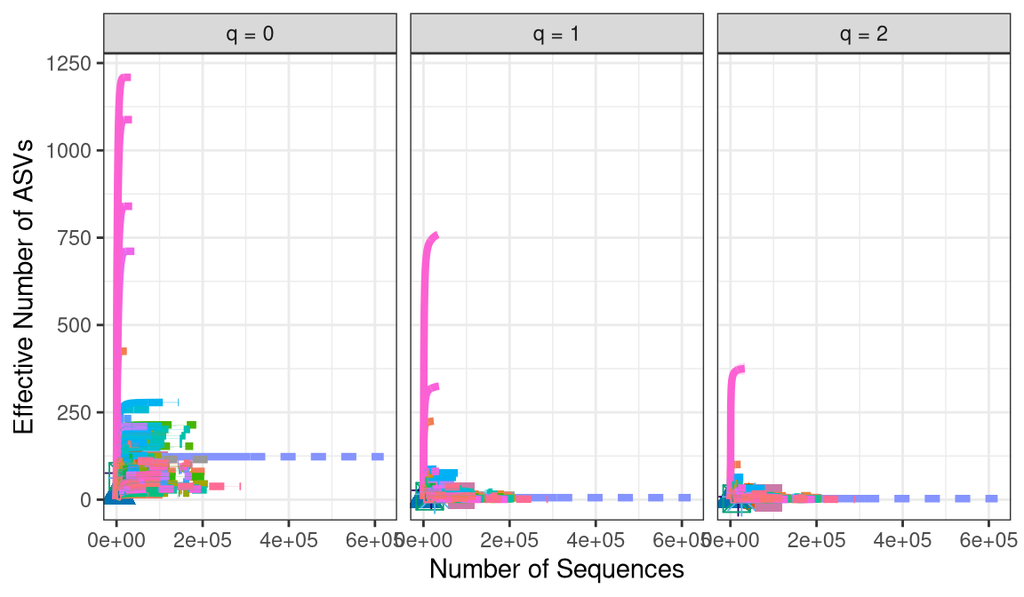

```r
ggiNEXT(iNEXT_data, type = 1, facet.var = "Order.q") +
  theme_bw() +
  theme(legend.position = "none") +
  labs(y = "Effective Number of ASVs", x = "Number of Sequences")
```

Remembering that an Order q of:

- 0 = Richness / Number of Total taxa
- 1 = Exponential Shannon / Number of “Common” taxa
- 2 = Inverse Simpson / Number of “Dominant” taxa

*Also note that iNEXT will extrapolate the number of sequences to double the sequencing depth of the sample!* This extrapolation is represented by the dotted line, which extends to 2 x the library size of the sample.

Ok, this plot is nice, but since it’s autogenerated with the `ggiNEXT` function, I’d like some more freedom to plot and explore the data further. Let’s manually plot the data that we pull out from the iNEXT data.

## Manual Rarefaction Curves

```r
str(iNEXT_data)
```

```
## List of 3
##  $ DataInfo:'data.frame':    117 obs. of  14 variables:
##   ..$ Assemblage: chr [1:117] "SRR8438042_R1_filtered.fastq.gz" "SRR8438043_R1_filtered.fastq.gz" "SRR8438044_R1_filtered.fastq.gz" "SRR8438045_R1_filtered.fastq.gz" ...
##   ..$ n         : num [1:117] 42740 4038 88323 18084 14546 ...
##   ..$ S.obs     : num [1:117] 110 15 101 76 67 62 26 115 159 14 ...
##   ..$ SC        : num [1:117] 1 1 1 1 1 1 1 1 1 1 ...
##   ..$ f1        : num [1:117] 0 0 0 0 0 0 0 0 0 0 ...
##   ..$ f2        : num [1:117] 0 0 0 0 0 0 0 0 9 0 ...
##   ..$ f3        : num [1:117] 2 0 0 0 2 0 1 0 19 0 ...
##   ..$ f4        : num [1:117] 0 1 1 0 0 0 0 2 15 1 ...
##   ..$ f5        : num [1:117] 0 1 1 0 0 0 1 1 9 0 ...
##   ..$ f6        : num [1:117] 0 0 0 0 0 0 0 2 6 0 ...
##   ..$ f7        : num [1:117] 0 0 0 1 0 0 0 1 15 1 ...
##   ..$ f8        : num [1:117] 0 0 0 0 0 0 1 0 13 1 ...
##   ..$ f9        : num [1:117] 0 0 0 0 0 0 0 4 6 0 ...
##   ..$ f10       : num [1:117] 0 0 0 0 2 0 0 4 5 0 ...
##  $ iNextEst:List of 2
##   ..$ size_based    :'data.frame':   14040 obs. of  10 variables:
##   .. ..$ Assemblage: chr [1:14040] "SRR8438042_R1_filtered.fastq.gz" "SRR8438042_R1_filtered.fastq.gz" "SRR8438042_R1_filtered.fastq.gz" "SRR8438042_R1_filtered.fastq.gz" ...
##   .. ..$ m         : num [1:14040] 1 2375 4749 7124 9498 ...
##   .. ..$ Method    : chr [1:14040] "Rarefaction" "Rarefaction" "Rarefaction" "Rarefaction" ...
##   .. ..$ Order.q   : num [1:14040] 0 0 0 0 0 0 0 0 0 0 ...
##   .. ..$ qD        : num [1:14040] 1 104 108 109 109 ...
##   .. ..$ qD.LCL    : num [1:14040] 1 104 107 108 108 ...
##   .. ..$ qD.UCL    : num [1:14040] 1 105 108 109 110 ...
##   .. ..$ SC        : num [1:14040] 0.104 0.997 0.999 1 1 ...
##   .. ..$ SC.LCL    : num [1:14040] 0.102 0.997 0.999 1 1 ...
##   .. ..$ SC.UCL    : num [1:14040] 0.106 0.997 0.999 1 1 ...
##   ..$ coverage_based:'data.frame':   6696 obs. of  8 variables:
##   .. ..$ Assemblage: chr [1:6696] "SRR8438042_R1_filtered.fastq.gz" "SRR8438042_R1_filtered.fastq.gz" "SRR8438042_R1_filtered.fastq.gz" "SRR8438042_R1_filtered.fastq.gz" ...
##   .. ..$ SC        : num [1:6696] 0.104 0.997 0.999 1 1 ...
##   .. ..$ m         : num [1:6696] 1 2375 4749 7124 9498 ...
##   .. ..$ Method    : chr [1:6696] "Rarefaction" "Rarefaction" "Rarefaction" "Rarefaction" ...
##   .. ..$ Order.q   : num [1:6696] 0 0 0 0 0 0 0 0 0 0 ...
##   .. ..$ qD        : num [1:6696] 1 104 108 109 109 ...
##   .. ..$ qD.LCL    : num [1:6696] 0.987 103.564 107.056 107.884 108.226 ...
##   .. ..$ qD.UCL    : num [1:6696] 1.01 104.75 108.24 109.23 109.7 ...
##  $ AsyEst  :'data.frame':    351 obs. of  7 variables:
##   ..$ Assemblage: chr [1:351] "SRR8438042_R1_filtered.fastq.gz" "SRR8438042_R1_filtered.fastq.gz" "SRR8438042_R1_filtered.fastq.gz" "SRR8438043_R1_filtered.fastq.gz" ...
##   ..$ Diversity : chr [1:351] "Species richness" "Shannon diversity" "Simpson diversity" "Species richness" ...
##   ..$ Observed  : num [1:351] 110 26.94 9.64 15 6.26 ...
##   ..$ Estimator : num [1:351] 110 26.98 9.64 15 6.28 ...
##   ..$ s.e.      : num [1:351] 0.2843 0.2094 0.0978 0.15 0.1049 ...
##   ..$ LCL       : num [1:351] 110 26.57 9.45 15 6.07 ...
##   ..$ UCL       : num [1:351] 110.56 27.39 9.83 15.29 6.48 ...
##  - attr(*, "class")= chr "iNEXT"
```

```r
iNEXT_manual_df <-
  iNEXT_data$iNextEst$size_based %>%
  dplyr::rename(names = Assemblage) %>%
  left_join(metadata_df, by = "names")

# Inspection
dim(iNEXT_manual_df)
```

```
## [1] 14040    46
```

```r
table(iNEXT_manual_df$tissue_group, useNA = "ifany")
```

```
##
##     Luminous Non-luminous
##         5400         8640
```

```r
table(is.na(iNEXT_manual_df$isolation_source))
```

```
##
## FALSE
## 14040
```

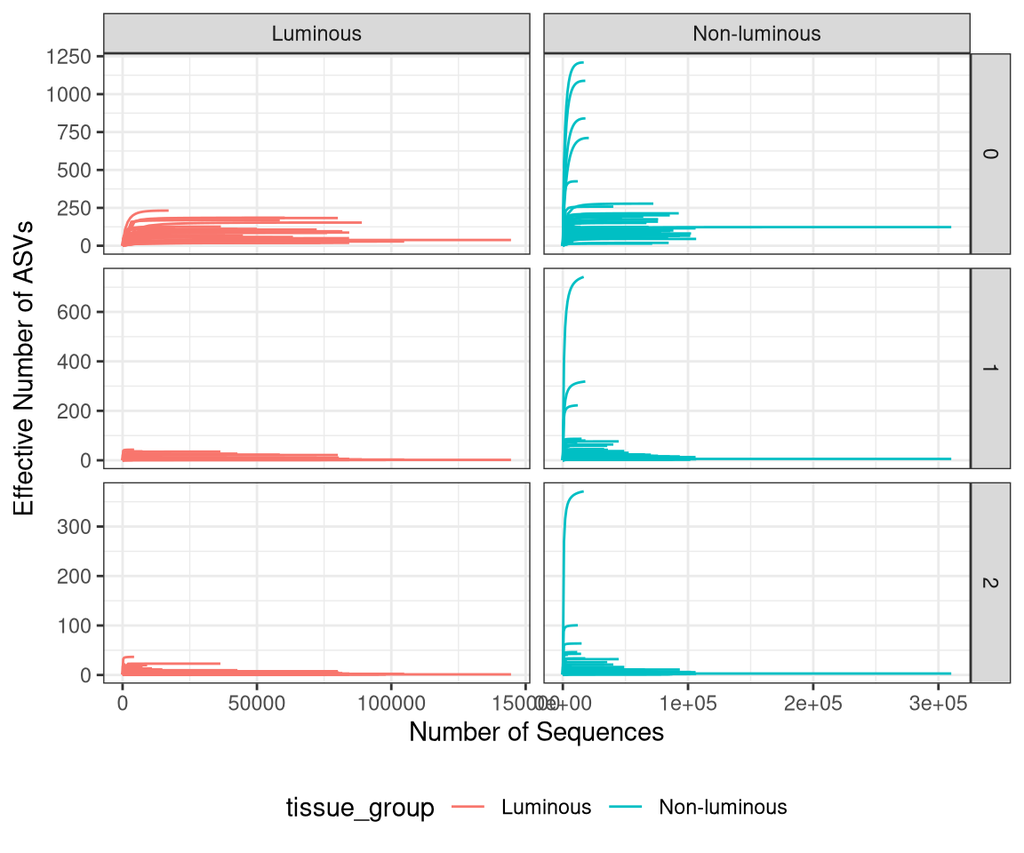

```r
# Manually plot rarefaction curves
iNEXT_manual_df %>%
  dplyr::filter(Method == "Rarefaction") %>%
  ggplot(aes(x = m, y = qD, color = tissue_group, group = names)) +
  geom_line() +
  facet_grid(Order.q ~ tissue_group, scales = "free") +
  theme_bw() +
  labs(y = "Effective Number of ASVs", x = "Number of Sequences") +
  theme(legend.position = "bottom")
```

INTERPRETATION #1: What can you conclude from the ggiNEXT and manual rarefaction curve plots? Are there “enough” sequences to analyze the samples? Is it valid to make any conclusions about species richness when q = 0? What about when q = 1? Or q = 2? Why or why not?

The ggiNEXT and manual rarefaction curve plots show that most samples begin to plateau, especially for q = 1 and q = 2, and many sequences are plateauing very early. This suggests that there are generally enough sequences to analyze the samples, particularly for Shannon diversity and Simpson diversity, which are less sensitive to rare ASVs and sequencing depth, but some ASVs are not as deep as I would like for a higher quality read. Richness (q = 0) is the most sensitive to sequencing depth, especially because a few samples still appear more compressed, and some higher-depth outliers stretch the axes. Even so, many of the richness curves do appear to approach saturation, suggesting that richness comparisons are possible, but with more caution than for q = 1 or q = 2. The q = 0 richness plot also hints at a lot of rare taxa present, which makes sense given the extreme conditions in the deep sea. The few pink outliers seen on the ggiNEXT plot with very high numbers of ASVs are only seen in non-luminous body regions, which is strange since I would expect outliers to be the bioluminescent symbionts. Overall I would like to see deeper reads but I think I have enough to make conclusions about all q-values. Looking into it a bit, it seems like the compressed nature of the luminous regions can hint at a more specialized group of ASVs, which would explain these plots.

# Statistical Testing

So, how do we actually quantify the changes in biodiversity that we may observe between the samples? That takes us into statistics!

## Parametric vs. Non-Parametric Statistics??

Understanding the difference between **parametric** and **non-parametric** statistics is essential for choosing the right test for your data, especially in microbial ecology where data often violate assumptions of normality.

*So, what’s the difference between the two?*

| Feature | Parametric | Non-Parametric |
| --- | --- | --- |
| **Assumptions** | Assumes a known distribution (usually normal) | Fewer assumptions about distribution |
| **Data Type** | Continuous (interval/ratio) | Ordinal or non-normal continuous |
| **Examples** | t-test, ANOVA, linear regression | Wilcoxon, Kruskal-Wallis, Spearman |
| **Estimates Based On** | Parameters like mean and variance | Ranks or medians |
| **Sensitive to Outliers?** | Yes | Less sensitive |
| **Statistical Power** | Higher if assumptions are met | Lower but more robust to violations |

### Parametric Statistics

Parametric tests assume that the data follow a specific distribution (usually a normal/Gaussian distribution). They are more statistically powerful **if those assumptions are met**.

### Non-Parametric Statistics

Non-parametric tests do not assume a specific data distribution and are more robust to outliers. Some examples include Wilcoxon tests to compare diversity between sample types. Non-parametric tests are ideal when:

- Data are skewed or non-normal
- Sample sizes are small
- Outliers are present
- You’re analyzing ranks or medians

## How do I test if my data is “normal”?

Typically people perform a **Shapiro-Wilk Test** on their data. The Shapiro-Wilk test is a statistical test used to check whether a sample of data comes from a normally distributed population.

- *Null hypothesis (H₀):* The data are normally distributed.
  - *p-value > 0.05*: Fail to reject H₀ and the data appears normal.
- *Alternative hypothesis (H₁):* The data are *not* normally distributed.
  - *p-value < 0.05*: We can reject the H₀, which indicates that the data is **not normal**.

## Prepare Observed Diversity Data

```r
obs_div_df <-
  iNEXT_manual_df %>%
  dplyr::filter(Method == "Observed")

# check it
glimpse(obs_div_df)
```

```
## Rows: 351
## Columns: 46
## $ names                          <chr> "SRR8438042_R1_filtered.fastq.gz", "SRR…
## $ m                              <dbl> 42740, 42740, 42740, 4038, 4038, 4038, …
## $ Method                         <chr> "Observed", "Observed", "Observed", "Ob…
## $ Order.q                        <dbl> 0, 1, 2, 0, 1, 2, 0, 1, 2, 0, 1, 2, 0, …
## $ qD                             <dbl> 110.000000, 26.944014, 9.640571, 15.000…
## $ qD.LCL                         <dbl> 109.356621, 26.506381, 9.466975, 14.529…
## $ qD.UCL                         <dbl> 110.643379, 27.381646, 9.814167, 15.470…
## $ SC                             <dbl> 1, 1, 1, 1, 1, 1, 1, 1, 1, 1, 1, 1, 1, …
## $ SC.LCL                         <dbl> 0.9999799, 0.9999799, 0.9999799, 1.0000…
## $ SC.UCL                         <dbl> 1, 1, 1, 1, 1, 1, 1, 1, 1, 1, 1, 1, 1, …
## $ Run                            <chr> "SRR8438042", "SRR8438042", "SRR8438042…
## $ Assay.Type                     <chr> "AMPLICON", "AMPLICON", "AMPLICON", "AM…
## $ AvgSpotLen                     <int> 500, 500, 500, 500, 500, 500, 500, 500,…
```

[output cut: 33 more lines]

## Check Normality of Richness, Shannon, and Simpson

```r
obs_rich_df <-
  obs_div_df %>%
  dplyr::filter(Order.q == 0)

shapiro.test(obs_rich_df$qD)
```

```
##
##  Shapiro-Wilk normality test
##
## data:  obs_rich_df$qD
## W = 0.48449, p-value < 2.2e-16
```

```r
obs_shannon_df <-
  obs_div_df %>%
  dplyr::filter(Order.q == 1)

shapiro.test(obs_shannon_df$qD)
```

```
##
##  Shapiro-Wilk normality test
##
## data:  obs_shannon_df$qD
## W = 0.28712, p-value < 2.2e-16
```

```r
obs_simps_df <-
  obs_div_df %>%
  dplyr::filter(Order.q == 2)

shapiro.test(obs_simps_df$qD)
```

```
##
##  Shapiro-Wilk normality test
##
## data:  obs_simps_df$qD
## W = 0.25769, p-value < 2.2e-16
```

# All tests are showing non normal resuts

# Categorical Analysis: 2 groups

Here, my question regarding alpha diversity is related to tissue type. In this case, I have a continuous biodiversity measure on the y-axis and a categorical variable on the x-axis.

### Diversity by Tissue Group

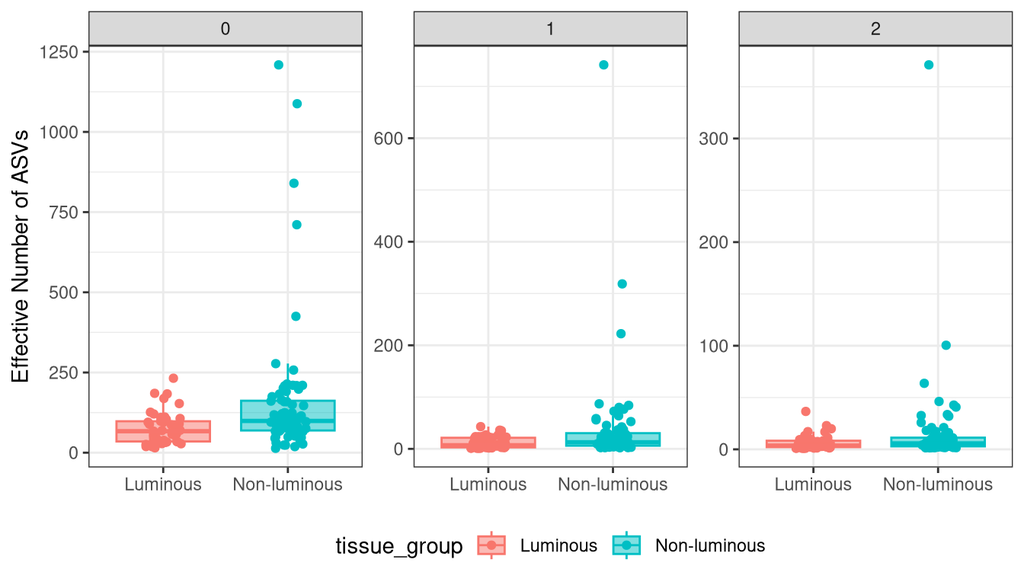

```r
obs_div_df %>%
  ggplot(aes(x = tissue_group, y = qD, fill = tissue_group,
             color = tissue_group)) +
  facet_wrap(.~Order.q, scales = "free_y") +
  geom_jitter(width = 0.15) +
  geom_boxplot(alpha = 0.5, outlier.shape = NA) +
  labs(y = "Effective Number of ASVs") +
  theme_bw() +
  theme(legend.position = "bottom",
        axis.title.x = element_blank())
```

### Richness vs Tissue Group

```r
# Pull out richness data
obs_rich_df <-
  obs_div_df %>%
  dplyr::filter(Order.q == 0)

# Calculate Wilcoxon test
wilcox_tissueGroup_rich <-
  wilcox.test(qD ~ tissue_group, data = obs_rich_df)

# Look at it
wilcox_tissueGroup_rich
```

```
##
##  Wilcoxon rank sum test with continuity correction
##
## data:  qD by tissue_group
## W = 1017, p-value = 0.0007364
## alternative hypothesis: true location shift is not equal to 0
```

```r
# Richness by tissue group
rich_ggboxplot <-
  ggboxplot(obs_rich_df, x = "tissue_group", y = "qD",
            color = "tissue_group", fill = "tissue_group", alpha = 0.3,
            outlier.shape = NA) +
  geom_jitter(aes(color = tissue_group), width = 0.15) +
  labs(y = "# of Total ASVs (Richness)") +
  stat_compare_means(method = "wilcox.test",
                     label.y = max(obs_rich_df$qD) * 1.05) +
  theme_bw() +
  theme(legend.position = "none",
        axis.title.x = element_blank())
```

### Shannon vs Tissue Group

```r
# Pull out shannon data
obs_shannon_df <-
  obs_div_df %>%
  dplyr::filter(Order.q == 1)

# Calculate Wilcoxon test
wilcox_tissueGroup_shannon <-
  wilcox.test(qD ~ tissue_group, data = obs_shannon_df)

# Look at it
wilcox_tissueGroup_shannon
```

```
##
##  Wilcoxon rank sum test with continuity correction
##
## data:  qD by tissue_group
## W = 1144, p-value = 0.007723
## alternative hypothesis: true location shift is not equal to 0
```

```r
# Shannon by tissue group
shannon_ggboxplot <-
  ggboxplot(obs_shannon_df, x = "tissue_group", y = "qD",
            color = "tissue_group", fill = "tissue_group", alpha = 0.3,
            outlier.shape = NA) +
  geom_jitter(aes(color = tissue_group), width = 0.15) +
  labs(y = "# of Common ASVs (Shannon)") +
  stat_compare_means(method = "wilcox.test",
                     label.y = max(obs_shannon_df$qD) * 1.05) +
  theme_bw() +
  theme(legend.position = "none",
        axis.title.x = element_blank())
```

### Simpson vs Tissue Group

```r
# Pull out simpson data
obs_simps_df <-
  obs_div_df %>%
  dplyr::filter(Order.q == 2)

# Calculate Wilcoxon test
wilcox_tissueGroup_simps <-
  wilcox.test(qD ~ tissue_group, data = obs_simps_df)

# Look at it
wilcox_tissueGroup_simps
```

```
##
##  Wilcoxon rank sum test with continuity correction
##
## data:  qD by tissue_group
## W = 1265, p-value = 0.04703
## alternative hypothesis: true location shift is not equal to 0
```

```r
# Simpson by tissue group
simps_ggboxplot <-
  ggboxplot(obs_simps_df, x = "tissue_group", y = "qD",
            color = "tissue_group", fill = "tissue_group", alpha = 0.3,
            outlier.shape = NA) +
  geom_jitter(aes(color = tissue_group), width = 0.15) +
  labs(y = "# of Dominant ASVs (Simpson)") +
  stat_compare_means(method = "wilcox.test",
                     label.y = max(obs_simps_df$qD) * 1.05) +
  theme_bw() +
  theme(legend.position = "none",
        axis.title.x = element_blank())
```

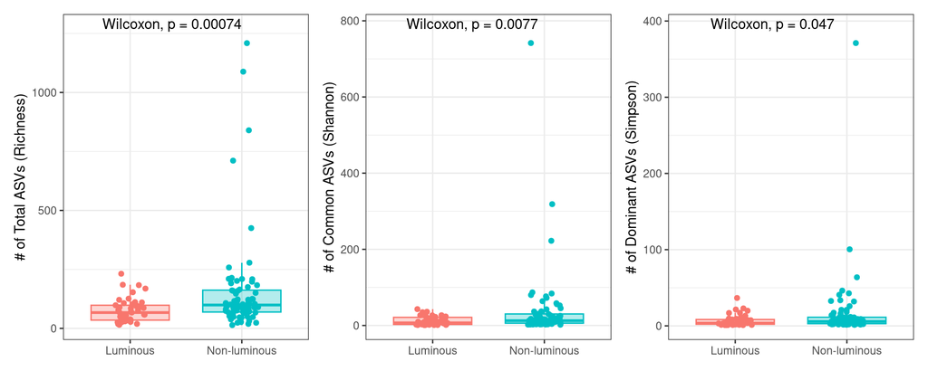

```r
rich_ggboxplot + shannon_ggboxplot + simps_ggboxplot
```

INTERPRETATION #2: If you have categorical data, what can you conclude regarding the role that all ASVs (richness, q = 0) versus common ASVs (Shannon, q = 1) versus dominant ASVs (Simpson, q = 2) have on the biodiversity of your samples as it relates to your variable of interest?

My categorical variable of interest luminous tissues vs non-luminous tissues. All q values were significantly different between luminious and non-luminous tissues. Richness (q = 0) suggests that luminous and non-luminous tissues differ in the total number of ASVs present. Shannon diversity (q = 1) suggests that the effective number of common ASVs differs between tissue types as well. Simpson diversity (q = 2) was less strongly significant than the others, which suggests that the dominant ASVs differ between luminous and non-luminous tissues, but there might be some contamination of the endosymbiont in non luminous tissues and remains somewhat ubiquitous everywhere. Overall, this means the biodiversity differences are not only being driven by rare taxa. Based on the boxplots, non-luminous tissues appear more diverse and much more variable overall, while luminous tissues appear tighter and generally lower in biodiversity, which fits the idea that luminous tissues may host more specialized bacterial communities.

INTERPRETATION #3: How did you statistically test your scientific question in Interpretation #2? Why?

I statistically tested my categorical biodiversity question by comparing luminous versus non-luminous tissue groups using Wilcoxon rank-sum tests for each biodiversity metric separately. I used this approach because tissue group is a categorical variable with two levels, while richness, Shannon diversity, and Simpson diversity are continuous variables. I first checked for normality with Shapiro-Wilk tests, and all three biodiversity measures were significantly non-normal, so a non-parametric test was appropriate. The Wilcoxon test was therefore a better choice because it does not assume normality. This allowed me to test whether biodiversity differed significantly between luminous and non-luminous tissues for each Hill diversity order using p values with an alpha value of 0.05.

```r
# Take the time now that we are at the end of the script
end_time <- Sys.time()
end_time
```

```
## [1] "2026-04-17 15:08:39 EDT"
```

```r
# Echo the elapsed time
elapsed_time <- round((end_time - start_time), 3)
elapsed_time
```

```
## Time difference of 11.32 secs
```